# Selección de variables con conjunto de datos LendingClub

Juan Gómez Romero

Selección de variables con el dataset [Lending Club](https://www.lendingclub.com/info/download-data.action).

[Lending Club](https://www.lendingclub.com/) es una financiera p2p (*peer to peer*) que ofrece información anonimizada sobre sus clientes. En este ejemplo utilizaremos un conjunto de datos sobre los préstamos (*loans*) vigentes en el último trimestre de 2017. El objetivo final es construir un modelo que prediga el estado de un préstamo (`loan status`) a partir del resto de variables. Se consideran los siguientes estados:

- No pagado (‘Unpaid’)
  - ‘Late (16-30 days)’
  - ‘Late (31-120 days)’
  - ‘In Grace Period’
  - ‘Charged Off’
- Pagado (‘Paid’)
  - ‘Current’

**Índice**

- 1. Lectura de datos
- 2. Eliminar columnos no útiles
- 3. Eliminar filas no útiles
- 4. Recodificar valores de clase objetivo
- 5. Identificar columnos según correlación
- 6. Guardar fichero

# 1. Lectura de datos

Comenzamos leyendo los datos disponibles. Podemos utilizar *n_max* para limitar la cantidad de filas con las que queremos trabajar y especificar con *na* qué valores queremos que se codifiquen como valores perdidos de R.

```r
data_raw <- read_csv('LoanStats_2017Q4.csv', na = c('NA', 'n/a', '', ' '))  # n_max = 10000
head(data_raw)
```

```
## # A tibble: 6 x 145
##   id    member_id loan_amnt funded_amnt funded_amnt_inv term  int_rate
##   <lgl> <lgl>         <dbl>       <dbl>           <dbl> <chr> <chr>
## 1 NA    NA            35000       35000           35000 60 m… 11.99%
## 2 NA    NA             6000        6000            6000 36 m… 7.35%
## 3 NA    NA            40000       40000           40000 36 m… 6.08%
## 4 NA    NA            10000       10000           10000 60 m… 23.88%
## 5 NA    NA            27000       27000           27000 60 m… 9.93%
## 6 NA    NA            19000       19000           19000 36 m… 7.35%
## # … with 138 more variables: installment <dbl>, grade <chr>,
## #   sub_grade <chr>, emp_title <chr>, emp_length <chr>,
## #   home_ownership <chr>, annual_inc <dbl>, verification_status <chr>,
## #   issue_d <chr>, loan_status <chr>, pymnt_plan <chr>, url <lgl>,
## #   desc <lgl>, purpose <chr>, title <chr>, zip_code <chr>,
## #   addr_state <chr>, dti <dbl>, delinq_2yrs <dbl>,
## #   earliest_cr_line <chr>, inq_last_6mths <dbl>,
## #   mths_since_last_delinq <dbl>, mths_since_last_record <dbl>,
## #   open_acc <dbl>, pub_rec <dbl>, revol_bal <dbl>, revol_util <chr>,
## #   total_acc <dbl>, initial_list_status <chr>, out_prncp <dbl>,
## #   out_prncp_inv <dbl>, total_pymnt <dbl>, total_pymnt_inv <dbl>,
## #   total_rec_prncp <dbl>, total_rec_int <dbl>, total_rec_late_fee <dbl>,
## #   recoveries <dbl>, collection_recovery_fee <dbl>, last_pymnt_d <chr>,
## #   last_pymnt_amnt <dbl>, next_pymnt_d <chr>, last_credit_pull_d <chr>,
## #   collections_12_mths_ex_med <dbl>, mths_since_last_major_derog <dbl>,
## #   policy_code <dbl>, application_type <chr>, annual_inc_joint <dbl>,
## #   dti_joint <dbl>, verification_status_joint <chr>,
## #   acc_now_delinq <dbl>, tot_coll_amt <dbl>, tot_cur_bal <dbl>,
## #   open_acc_6m <dbl>, open_act_il <dbl>, open_il_12m <dbl>,
## #   open_il_24m <dbl>, mths_since_rcnt_il <dbl>, total_bal_il <dbl>,
## #   il_util <dbl>, open_rv_12m <dbl>, open_rv_24m <dbl>, max_bal_bc <dbl>,
## #   all_util <dbl>, total_rev_hi_lim <dbl>, inq_fi <dbl>,
## #   total_cu_tl <dbl>, inq_last_12m <dbl>, acc_open_past_24mths <dbl>,
## #   avg_cur_bal <dbl>, bc_open_to_buy <dbl>, bc_util <dbl>,
## #   chargeoff_within_12_mths <dbl>, delinq_amnt <dbl>,
## #   mo_sin_old_il_acct <dbl>, mo_sin_old_rev_tl_op <dbl>,
## #   mo_sin_rcnt_rev_tl_op <dbl>, mo_sin_rcnt_tl <dbl>, mort_acc <dbl>,
## #   mths_since_recent_bc <dbl>, mths_since_recent_bc_dlq <dbl>,
## #   mths_since_recent_inq <dbl>, mths_since_recent_revol_delinq <dbl>,
## #   num_accts_ever_120_pd <dbl>, num_actv_bc_tl <dbl>,
## #   num_actv_rev_tl <dbl>, num_bc_sats <dbl>, num_bc_tl <dbl>,
## #   num_il_tl <dbl>, num_op_rev_tl <dbl>, num_rev_accts <dbl>,
## #   num_rev_tl_bal_gt_0 <dbl>, num_sats <dbl>, num_tl_120dpd_2m <dbl>,
## #   num_tl_30dpd <dbl>, num_tl_90g_dpd_24m <dbl>,
## #   num_tl_op_past_12m <dbl>, pct_tl_nvr_dlq <dbl>,
## #   percent_bc_gt_75 <dbl>, pub_rec_bankruptcies <dbl>, tax_liens <dbl>, …
```

```r
status <- df_status(data_raw)
```

```
##                                       variable q_zeros p_zeros   q_na
## 1                                           id       0    0.00 118650
## 2                                    member_id       0    0.00 118650
## 3                                    loan_amnt       0    0.00      2
## 4                                  funded_amnt       0    0.00      2
## 5                              funded_amnt_inv       0    0.00      2
## 6                                         term       0    0.00      2
## 7                                     int_rate       0    0.00      2
## 8                                  installment       0    0.00      2
## 9                                        grade       0    0.00      2
## 10                                   sub_grade       0    0.00      2
## 11                                   emp_title       0    0.00   9870
## 12                                  emp_length       0    0.00   9724
## 13                              home_ownership       0    0.00      2
## 14                                  annual_inc     212    0.18      2
```

[output cut: 277 more lines]

# 2. Eliminar columnos no útiles

A continuación vamos a eliminar las columnas que no son útiles. Consideramos columnas no útiles las siguientes:

- Columnas con más del 90% de los valores a 0
- Columnas con más del 50% de los valores a NA
- Identificar columnas con <= 3 valores diferentes
- Identificar columnas >75% valores diferentes

Obviamente, esta selección es bastante tosca. Convendría justificar estas decisiones a partir de la semántica de las columnas.

Para ello, trabajaremos con la tabla *status*, que incluye una fila por cada variable y varias columnas especificando número y proporción de 0, NA, valores únicos, etc. Tomaremos de esta tabla los nombres de variables (columna *variable*) que cumplen determinados requisitos y después crearemos una lista (variable *remove_cols*), que se utiliará para borrar columnas. El resultado se guardará en *data*. No queremos eliminar ‘loan_status’, así que comenzaremos por excluirla de la tabla.

Excluir ‘loan_status’ de la tabla *status*:

```r
status <- status %>%
  filter(variable != 'loan_status')
```

Identificar columnas con más del 90% de los valores a 0:

```r
zero_cols <- status %>%
  filter(p_zeros > 90) %>%
  select(variable)
```

Identificar columnas con más del 50% de los valores a NA:

```r
na_cols <- status %>%
  filter(p_na > 50) %>%
  select(variable)
```

Identificar columnas con <= 3 valores diferentes:

```r
eq_cols <- status %>%
  filter(unique <= 3) %>%
  select(variable)
```

Identificar columnas >75% valores diferentes:

```r
dif_cols <- status %>%
  filter(unique > 0.75 * nrow(data_raw)) %>%
  select(variable)
```

Eliminar columnas excluidas:

```r
remove_cols <- bind_rows(
  list(
    zero_cols,
    na_cols,
    eq_cols,
    dif_cols
  )
)

data <- data_raw %>%
  select(-one_of(remove_cols$variable))
```

```r
head(data)
```

```
## # A tibble: 6 x 78
##   loan_amnt funded_amnt funded_amnt_inv int_rate installment grade
##       <dbl>       <dbl>           <dbl> <chr>          <dbl> <chr>
## 1     35000       35000           35000 11.99%          778. B
## 2      6000        6000            6000 7.35%           186. A
## 3     40000       40000           40000 6.08%          1218. A
## 4     10000       10000           10000 23.88%          287. E
## 5     27000       27000           27000 9.93%           573. B
## 6     19000       19000           19000 7.35%           590. A
## # … with 72 more variables: sub_grade <chr>, emp_title <chr>,
## #   emp_length <chr>, home_ownership <chr>, annual_inc <dbl>,
## #   loan_status <chr>, purpose <chr>, title <chr>, zip_code <chr>,
## #   addr_state <chr>, dti <dbl>, delinq_2yrs <dbl>,
## #   earliest_cr_line <chr>, inq_last_6mths <dbl>, open_acc <dbl>,
## #   pub_rec <dbl>, revol_bal <dbl>, revol_util <chr>, total_acc <dbl>,
## #   out_prncp <dbl>, out_prncp_inv <dbl>, total_pymnt <dbl>,
## #   total_pymnt_inv <dbl>, total_rec_prncp <dbl>, total_rec_int <dbl>,
## #   last_pymnt_d <chr>, last_pymnt_amnt <dbl>, last_credit_pull_d <chr>,
## #   tot_coll_amt <dbl>, open_acc_6m <dbl>, open_act_il <dbl>,
## #   open_il_12m <dbl>, open_il_24m <dbl>, mths_since_rcnt_il <dbl>,
## #   total_bal_il <dbl>, il_util <dbl>, open_rv_12m <dbl>,
## #   open_rv_24m <dbl>, max_bal_bc <dbl>, all_util <dbl>,
## #   total_rev_hi_lim <dbl>, inq_fi <dbl>, total_cu_tl <dbl>,
## #   inq_last_12m <dbl>, acc_open_past_24mths <dbl>, avg_cur_bal <dbl>,
## #   bc_open_to_buy <dbl>, bc_util <dbl>, mo_sin_old_il_acct <dbl>,
## #   mo_sin_old_rev_tl_op <dbl>, mo_sin_rcnt_rev_tl_op <dbl>,
## #   mo_sin_rcnt_tl <dbl>, mort_acc <dbl>, mths_since_recent_bc <dbl>,
## #   mths_since_recent_inq <dbl>, num_accts_ever_120_pd <dbl>,
## #   num_actv_bc_tl <dbl>, num_actv_rev_tl <dbl>, num_bc_sats <dbl>,
## #   num_bc_tl <dbl>, num_il_tl <dbl>, num_op_rev_tl <dbl>,
## #   num_rev_accts <dbl>, num_rev_tl_bal_gt_0 <dbl>, num_sats <dbl>,
## #   num_tl_op_past_12m <dbl>, pct_tl_nvr_dlq <dbl>,
## #   percent_bc_gt_75 <dbl>, pub_rec_bankruptcies <dbl>,
## #   total_bal_ex_mort <dbl>, total_bc_limit <dbl>,
## #   total_il_high_credit_limit <dbl>
```

```r
df_status(data)
```

```
##                      variable q_zeros p_zeros  q_na  p_na q_inf p_inf
## 1                   loan_amnt       0    0.00     2  0.00     0     0
## 2                 funded_amnt       0    0.00     2  0.00     0     0
## 3             funded_amnt_inv       0    0.00     2  0.00     0     0
## 4                    int_rate       0    0.00     2  0.00     0     0
## 5                 installment       0    0.00     2  0.00     0     0
## 6                       grade       0    0.00     2  0.00     0     0
## 7                   sub_grade       0    0.00     2  0.00     0     0
## 8                   emp_title       0    0.00  9870  8.32     0     0
## 9                  emp_length       0    0.00  9724  8.20     0     0
## 10             home_ownership       0    0.00     2  0.00     0     0
## 11                 annual_inc     212    0.18     2  0.00     0     0
## 12                loan_status       0    0.00     2  0.00     0     0
## 13                    purpose       0    0.00     2  0.00     0     0
## 14                      title       0    0.00     2  0.00     0     0
```

[output cut: 143 more lines]

# 3. Eliminar filas no útiles

```r
data <- data %>%
  filter(loan_status
         %in%
           c('Late (16-30 days)',
             'Late (31-120 days)',
             'In Grace Period',
             'Charged Off',
             'Current'))
```

# 4. Recodificar valores de clase objetivo

Vamos a convertir el problema en una clasificación binaria recodificando los valores de ‘loan_status’ a dos categorías: *Paid*, *Unpaid*. La clase mayoritaria es *Paid* y consideraremos “clase positiva” a *Unpaid* (los casos interesantes de detectar son aquellos en que no se paga el préstamo).

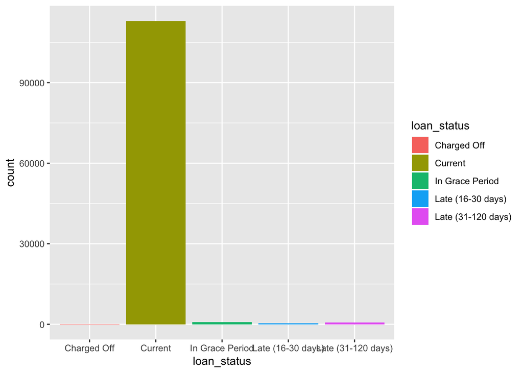

```r
ggplot(data) +
  geom_histogram(aes(x = loan_status, fill = loan_status), stat = 'count')
```

```r
data <- data %>%
  mutate(loan_status = case_when(
    loan_status == 'Late (16-30 days)'  ~ 'Unpaid',
    loan_status == 'Late (31-120 days)' ~ 'Unpaid',
    loan_status == 'In Grace Period'    ~ 'Unpaid',
    loan_status == 'Charged Off'        ~ 'Unpaid',
    loan_status == 'Current'            ~ 'Paid'))
```

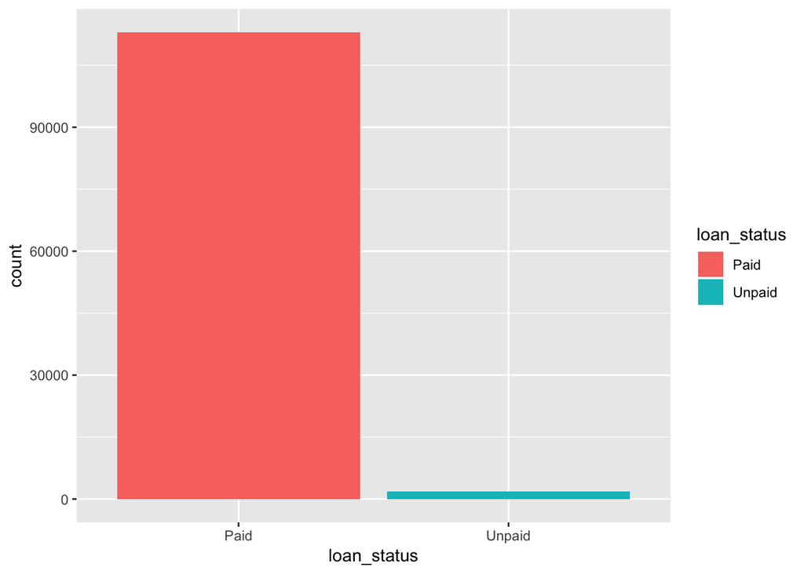

```r
ggplot(data) +
  geom_histogram(aes(x = loan_status, fill = loan_status), stat = 'count')
```

# 5. Identificar columnos según correlación

Vamos a continuar seleccionando columnas. Comenzaremos seleccionando las columnas que tienen una alta correlación con la variable objetivo ‘loan_status’ y, por tanto, son interesantes (son buenos predictores de su comportamiento). Continuaremos estudiante las columnas que tienen una alta correlación entre sí y, por tanto, solo nos interesa una de ellas (todas aportan la misma información).

## 5.1 Alta correlacion con la variable objetivo

```r
# correlation_table(data, target='loan_status')
```

Para ello, eliminamos las filas con NAs usando *na.exclude()* y convertimos las cadenas a *factor* + los *factor* a números:

```r
data_num <- data %>%
  na.exclude() %>%
  mutate_if(is.character, as.factor) %>%
  mutate_if(is.factor, as.numeric)
```

Ahora sí podemos calcular la correlación:

```r
cor_target <- correlation_table(data_num, target='loan_status')
```

Y quedarnos solo con las variables que tienen una correlación por encima del 0.01 (en valor absoluto):

```r
important_vars <- cor_target %>%
  filter(abs(loan_status) >= 0.01)

data <- data %>%
  select(one_of(important_vars$Variable))
```

## 5.2 Alta correlación entre sí

Construirmos una tabla de correlación con todas las variables utilizando *rcorr*. Al igual que en el caso anterior, es necesario eliminar filas con valores NA y convertir las cadenas a valores numéricos.

```r
data_num <- data %>%
  na.exclude() %>%
  mutate_if(is.character, as.factor) %>%
  mutate_if(is.factor, as.numeric)
rcorr_result <- rcorr(as.matrix(data_num))
```

Para visualizar la matriz de correlación, utilizamos *corrplot* (previa transformación a *tibble*):

```r
cor_matrix <- as.tibble(rcorr_result$r, rownames = "variable")
```

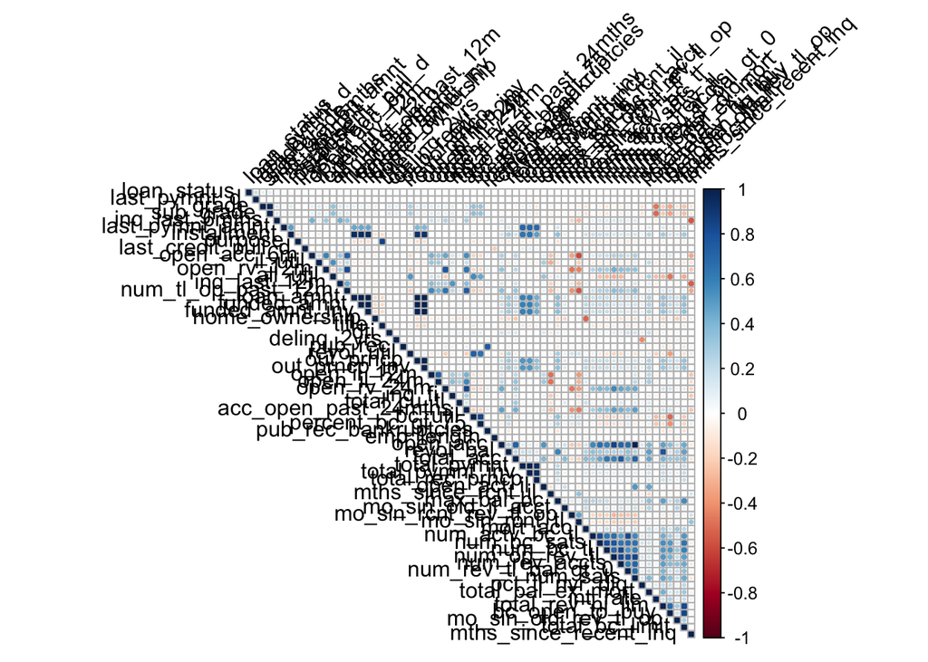

```r
corrplot(rcorr_result$r, type = "upper", order = "original", tl.col = "black", tl.srt = 45)
```

Se puede observar que hay varias variables con alto índice de correlación; en concreto: ‘open_rv_24m’, ‘acc_open_past_24mths’, ‘open_il_24m’, ‘total_rec_prncp’, ‘total_pymnt’, ‘total_pymnt_inv’, ‘grade’.

Vamos a agrupar las variables según el valor de correlación entre ellas ([coeficiente de Pearson](https://es.wikipedia.org/wiki/Coeficiente_de_correlaci%C3%B3n_de_Pearson)). Utilizaremos *varclus*, que crea un cluster jearárquico a partir de la similitud entre variables calculada a partir de la medida especificada:

```r
v <- varclus(as.matrix(data_num), similarity="pearson")
```

Podemos visualizar el cluster creado:

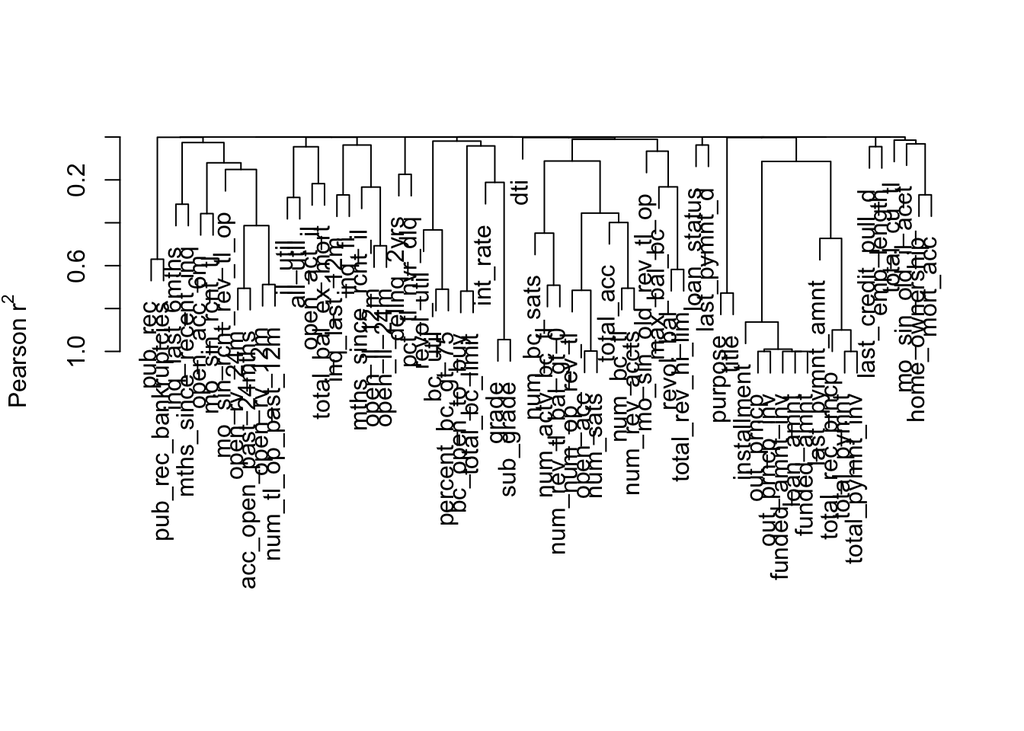

```r
plot(v)
```

Para quedarnos con las variables representativas, cortaremos el árbol de agrupaciones a una determinada altura para obtener los clusteres a esa altura. Esto se puede hacer especificando un valor de la medida de similitud (*Pearson*) o indicando el número de clusteres que queremos (dejando que la función interprete cómo debe realizar el corte). Utilizando la segunda opción podemos obtener 25 grupos:

```r
groups <- cutree(v$hclust, 25)
```

Finalmente, nos quedamos con una variable representativa de cada grupo, que será la que seleccionemos para el análisis. Para ello, hacemos un *group_by* por número de cluster asignado y seleccionamos una instancia con *sample_n*:

```r
not_correlated_vars <- enframe(groups) %>%
  group_by(value) %>%
  sample_n(1)
```

Y retenemos en *data* las variables elegidas:

```r
data <- data %>%
  select(one_of(not_correlated_vars$name))
```

# 6. Guardar fichero

Para terminar, guardamos los datos después de selección de variables:

```r
head(data)
```

```
## # A tibble: 6 x 25
##   loan_status last_pymnt_d sub_grade mths_since_rece… loan_amnt title
##   <chr>       <chr>        <chr>                <dbl>     <dbl> <chr>
## 1 Paid        Feb-2018     B5                      NA     35000 Debt…
## 2 Paid        Feb-2018     A4                       4      6000 Debt…
## 3 Paid        Feb-2018     A2                      NA     40000 Debt…
## 4 Paid        Feb-2018     E2                      NA     10000 Cred…
## 5 Paid        Feb-2018     B2                       8     27000 Debt…
## 6 Paid        Feb-2018     A4                       3     19000 Debt…
## # … with 19 more variables: last_credit_pull_d <chr>,
## #   acc_open_past_24mths <dbl>, all_util <dbl>, inq_last_12m <dbl>,
## #   home_ownership <chr>, dti <dbl>, pct_tl_nvr_dlq <dbl>, pub_rec <dbl>,
## #   percent_bc_gt_75 <dbl>, open_il_24m <dbl>, total_cu_tl <dbl>,
## #   emp_length <chr>, num_bc_tl <dbl>, total_rev_hi_lim <dbl>,
## #   total_bal_ex_mort <dbl>, mo_sin_old_il_acct <dbl>, num_bc_sats <dbl>,
## #   bc_open_to_buy <dbl>, mo_sin_old_rev_tl_op <dbl>
```

```r
df_status(data)
```

```
##                 variable q_zeros p_zeros  q_na  p_na q_inf p_inf      type
## 1            loan_status       0    0.00     0  0.00     0     0 character
## 2           last_pymnt_d       0    0.00   193  0.17     0     0 character
## 3              sub_grade       0    0.00     0  0.00     0     0 character
## 4  mths_since_recent_inq    7921    6.90 14487 12.62     0     0   numeric
## 5              loan_amnt       0    0.00     0  0.00     0     0   numeric
## 6                  title       0    0.00     0  0.00     0     0 character
## 7     last_credit_pull_d       0    0.00     8  0.01     0     0 character
## 8   acc_open_past_24mths    5653    4.92     0  0.00     0     0   numeric
## 9               all_util     360    0.31    36  0.03     0     0   numeric
## 10          inq_last_12m   34634   30.17     0  0.00     0     0   numeric
## 11        home_ownership       0    0.00     0  0.00     0     0 character
## 12                   dti     173    0.15   216  0.19     0     0   numeric
## 13        pct_tl_nvr_dlq       0    0.00     0  0.00     0     0   numeric
## 14               pub_rec   97458   84.89     0  0.00     0     0   numeric
```

[output cut: 37 more lines]

```r
write_csv(data, 'LoanStats_2017Q4-SelVar.csv')
```

El fichero final ya sí puede utilizarse para construir un modelo de predicción utilizando [`caret`](http://topepo.github.io/caret/).